# FAQ’s

Version 1

## **General**

### What services and pricing are available from TREx?

TREx offeres a variety of RNAseq and small RNA sequencing services. Please refer to our [Services and Pricing](https://www.rnaseqcore.vet.cornell.edu/services.html) page for information on standard services and pricing. For custom projects or any other questions, please reach out using our [Get in touch](https://www.rnaseqcore.vet.cornell.edu/home.html#Virtual) form for more information

### How do I submit samples to TREx?

First fill out a [BRC Order](https://www.rnaseqcore.vet.cornell.edu/forms.html) and e-mail it to trex_info@cornell.edu. Once we receive the form, we will reach out to you with further questions and to schedule a sample drop off if needed.

### Does TREx offer consultations?

Yes! We encourage consultations at any stage of a project, but particularly at early stages so that we can provide guidance and discuss any challenges or concerns to get your project moving in the right direction. Consultations are FREE, use our [Get in touch](https://www.rnaseqcore.vet.cornell.edu/home.html#Virtual) form to contact us to schedule a meeting. Currently, all meetings are virtual using zoom.

### What is the difference between TREx and the BRC Genomics Facility?

TREx offers complete services for genomics technologies related to gene regulation and expression. Our goal at TREx is to offer end-to-end genomic solutions, starting with consultation on project planning and sample QC prior to submission, moving through library prep and sequencing, and concluding with data QC and analysis. We believe that partnering with researchers for the full experimental cycle can be helpful, not only with sample and data quality assessment, but also with deriving biological insights from genomics datasets. The [Cornell BRC Genomics](https://www.biotech.cornell.edu/core-facilities-brc/facilities/genomics-facility) and [Bioinformatics Facilities](https://www.biotech.cornell.edu/core-facilities-brc/facilities/bioinformatics-facility) offer related services for Illumina sequencing and analysis. TREx works closely with the BRC Facilities to ensure that Cornell researchers have access to a wide variety of genomics services and support.

## **Project Planning**

### Do you have a recommended protocol for RNA Isolation?

Our preferred total RNA isolation protocol generates the best yields and retains small RNA’s. We have adapted a Trizol protocol to include additional steps that improve yield and purity, available [here](https://www.rnaseqcore.vet.cornell.edu/forms.html). Other methods using silica spin-columns or magnetic beads can generate RNA samples of equivalent quality appropriate for RNAseq and small RNA sequencing. If your project includes small RNA sequencing, take care that your RNA isolation method retains small RNAs (protocols and kits vary).

### How do I determine the quality of my RNA samples?

We consider three distinct elements of RNA sample quality: the **chemical purity**, the **biological integrity**, and the total **yield** (concentration x volume).

To assess **biological integrity**, we recommend using a Fragment Analyzer or similar instrument such as the Bioanalyzer or Tapestation. These instruments generate a trace of the RNA size distribution which indicates the degree of RNA degradation based on the shape of the rRNA peaks and the baseline. To interpret results, please refer to our [Fragment Analyzer RNA QC](https://www.rnaseqcore.vet.cornell.edu/forms.html) guide. We recommend using polyA+ RNAseq only for samples with Fragment Analyzer RQN > 7 or Bioanalyzer or Tapestation RIN > 8. For degraded RNA below these quality scores, we recommend rRNA depletion instead of polyA+ enrichment. For more information on which method of ribosomal depletion to choose, please refer to our [rRNA Depletion Methods](https://www.rnaseqcore.vet.cornell.edu/forms.html) guide.

To determine sample concentration and total **yield**, we recommend using a Nanodrop (A260 absorbance) for samples with concentrations greater than 20ng/uL. For concentrations lower than 20ng/uL we recommend using a Qubit or other intercalating dye system as the qubit is more sensitive. Ultra-low concentration samples (<5 ng/ul) may require using > 1 ul in a Qubit assay. [Contact us](https://www.rnaseqcore.vet.cornell.edu/home.html#Virtual) for recommendations for projects with ultra-low yield samples, where >10% of each sample would be consumed to determine sample integrity and yield.

### Why are biological replicates important, and how many are recommended?

Biological replicates are important for capturing the biological variation (noise) within your project, which is required to quantify signal > noise. The number of replicates needed for statistical power to detect signal > noise is dependent on the amount of biological variation within replicate groups (conditions) as well as the amount of signal between groups (conditions). Within-group variation may be small, such as for cells grown in culture, or it may be large, such as among clinical samples where there is less control over environmental variables. Therefore, experimental designs for projects using cultured often include fewer biological replicates than for projects using clinical samples. Note that biological replicates consist of independent samples reflecting the same condition (e.g. treatment, disease state, genotype); technical replicates (for example, multiple RNAseq libraries generated from one cell population or RNA sample) are typically not useful for biological discovery research. Biological replication is also critical for control samples for the same reason: statistical power to estimate variation (noise) for the control condition.

As a general rule of thumb we recommend at least 3 biological replicates per condition (e.g.projects with low intra-replicate variation), with higher numbers recommended for projects with more biological variation (e.g. clinical studies). Our standard analysis pipeline requires an absolute minimum of 2 biological replicates for each condition tested. We don;t recommend using RNAseq for projects with no biological replication, as analysis of differential gene expression requires the use of a very conservative statistical model for dispersion (noise) and there is no way to assess replicate consistency. If you have questions about how many replicates you need, please [Contact Us](https://www.rnaseqcore.vet.cornell.edu/home.html#Virtual).

### Can I request custom sequencing?

We offer deeper sequencing (beyond the standard depth included in the per-sample pricing) if your project requires more reads; see [pricing info](https://www.rnaseqcore.vet.cornell.edu/services.html). Deeper sequencing can be requested at the time of Project submission, or later for a library we have already sequenced (in most cases).If your project would benefit from a different Illumina run type, we can work with you to generate a custom quote that reflects your needs. In most cases, custom sequencing will have an increased price, as compared to our standard options.

## **RNA Sequencing**

### Why should I do RNASeq?

While there are many reasons to use RNASeq, we find that the most common is gene expression analysis, and this is the basis for our standard services (sequencing depth and standard analysis). For other uses, including transcriptome assembly and pathogen identification, please reach out using our [Get in touch](https://www.rnaseqcore.vet.cornell.edu/home.html#Virtual) form, as adjustments to our standard sequencing depth may be necessary to achieve your specific project goals.

### How much RNA do I need?

We recommend that you submit at least 2ug of total RNA in a minimum volume of 15uL for RNAseq. This allows us to use the minimum number of PCR cycles to decrease PCR biases and provides for backup material in case something were to go wrong. Any material we do not use can be returned to you when we are finished with your project.

### How will my RNAseq libraries be sequenced?

Our standard sequencing depth for RNAseq libraries is to generate at least 10 Million raw reads for cultured bacterial samples and 20 Million raw reads for eukaryotic samples or complex/environmental mixed samples, with the goal of achieving at least 5M or 10M reads mapped to the reference transcriptome, respectively. Our standard sequencing mode is now 2x150 PE reads for RNAseq on the HiSeq or NovaSeq platforms; our minimum target depth is 10M or 20M PE reads (20M or 40M individual reads) per sample.

We understand that sometimes specific project goals may require custom read length or sequencing depth and are able to accommodate this. For custom projects please reach out using our [Get in touch](https://www.rnaseqcore.vet.cornell.edu/home.html#Virtual) form to schedule a meeting or schedule a virtual appointment to discuss your project needs.

### What is the difference between **PolyA selection** and **Ribosomal depletion** and/or how would I select a method?

**PolyA Selection** and **Ribosomal depletion** are the two most common methods used to remove the ribosomal RNA from total RNA prior to making an RNAseq library.

**PolyA Selection** accomplishes this by positively enriching for polyadenylated messenger RNAs (mRNAs). Oligo-dT sequences coupled to magnetic beads bind polyA sequences; following hybridization, the beads are washed to get rid of ribosomal RNAs and other non-mRNA transcripts. With this method, it is important to have intact RNA (RNA with an RQN>7 on a Fragment Analyzer), otherwise there will be a strong 3’ bias in the resulting RNAseq library. PolyA selection gives the best data quality for coding genes (mRNAs) but does not retain non-polyadenylated transcripts.

**Ribosomal depletion** uses a negative selection process to specifically remove ribosomal RNA sequences. In our method, predesigned probes are used to bind to the ribosomal RNA, followed by enzymatic degradation of the RNA/DNA hybrids. This method can have variable performance for different species, depending on probe design. We use kits from NEB that is designed to deplete mammalian rRNA or broad-spectrum bacterial rRNA (we do not have a plant rRNA depletion kit in stock). This method is not as effective at removing ribosmal RNA as the PolyA selection method, though it can accommodate samples with an RQN<7 and is sometimes necessary for specific project aims such as bacterial gene expression profiling or for pathogen identification (including bacteria and viruses).

When selecting which method is a good choice for you, we recommend you refer to the graphic below and our [rRNA Depletion Methods](https://www.rnaseqcore.vet.cornell.edu/files/TRExGuide_rRNAdepletionmethods.pdf) guide.

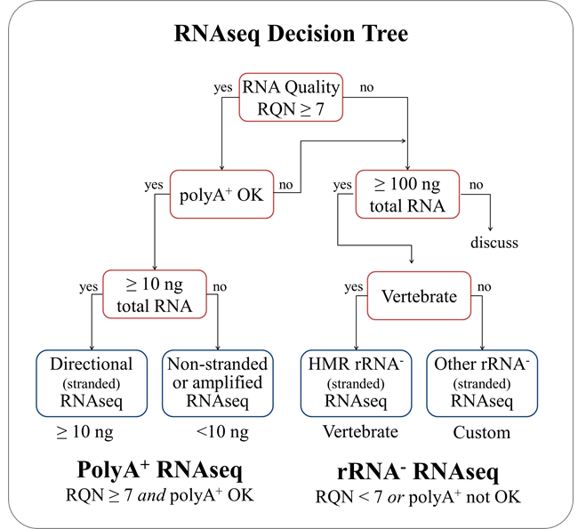

### How do you prepare RNAseq libraries?

We use [NEB Next Ultra II](https://www.neb.com/applications/ngs-sample-prep-and-target-enrichment/illumina-library-preparation/nebnext-ultra-ii-rna-library-prep) kits to prepare RNAseq libraries, including pre-enrichment steps.

## **Small RNA**

### Why should I use small RNA sequencing for my research?

While there are many reasons to do small RNA sequencing, we find the most common is to profile mature microRNAs (miRNAs) and related regulatory RNAs (< ~30nt in length, including siRNAs and piRNAs). Our standard library preparation protocol enriches for insert sizes ~15-35nt, and our standard analysis pipeline focuses on annotated miRNAs in [miRBase](http://www.mirbase.org/). For other small RNA sequencing applications please reach out using our [Get in touch](https://www.rnaseqcore.vet.cornell.edu/home.html#Virtual) form, as minor tweaks to library size selection or sequencing read depth may be necessary to achieve your specific project goals.

### How much material do I need?

For total RNA samples extracted from cells, we recommend that you submit at least 100ng for small RNA sequencing, based on the minimum input requirements for the [NEBNext small RNA library preparation kit](https://www.neb.com/products/e7300-nebnext-multiplex-small-rna-library-prep-set-for-illumina-set-1). For projects using cell free RNA or RNA from extracellular vesicles (EVs), the minimum input requirements are much lower because these sample types are pre-enriched for small RNAs. For special sample type considerations, please reach out to us using our [Get in touch](https://www.rnaseqcore.vet.cornell.edu/home.html#Virtual) form or schedule a meeting to discuss.

### What is the sequencing strategy?

Our target sequencing depth for small RNA libraries is a minimum of 10 Million raw reads per sample. We find that the miRNA-mapping rate can be very variable, but robust miRNA profiles can be generated with 1M miRNA-mapped reads or even less. We understand that sometimes specific project goals may require custom sequencing depth. For custom projects please reach out using our [Get in touch](https://www.rnaseqcore.vet.cornell.edu/home.html#Virtual) form or schedule a meeting to discuss.

## **Analysis**

### What is the default analysis pipeline for TREx services?

All TREx pipelines are built around ENCODE standards and practices. When available, we use reference genome and gene annotation files from [Ensembl](http://useast.ensembl.org/index.html). For more details, see the [Analysis](https://www.rnaseqcore.vet.cornell.edu/analysis.html) section of our web site.

For RNAseq: Raw fastq files are first processed with [trim-galore](https://github.com/FelixKrueger/TrimGalore/blob/master/Docs/Trim_Galore_User_Guide.md) to trim low quality bases and adapter sequences and filter short inserts. Trimmed reads are then aligned to the reference genome using [STAR](https://academic.oup.com/bioinformatics/article/29/1/15/272537).

For gene expression profiling, raw count tables generated by STAR for annotated genes (–quantMode GeneCounts) are analyzed with [DESeq2](https://bioconductor.org/packages/release/bioc/vignettes/DESeq2/inst/doc/DESeq2.html).

We can support other analysis goals such as dual RNAseq (profiling expression of more than one known organism) and pathogen discovery; [contact us](https://www.rnaseqcore.vet.cornell.edu/home.html#Virtual) for more information.

For small RNA sequencing: Raw single-end reads are first processed with [trim-galore](https://github.com/FelixKrueger/TrimGalore/blob/master/Docs/Trim_Galore_User_Guide.md) package to trim for low quality bases and adapter sequences. Trimmed reads are then analyzed using [mirDeep2](https://www.mdc-berlin.de/content/mirdeep2-documentation) to generate counts for mature miRNAs annotated in [miRBase](http://www.mirbase.org/). Novel miRNA discovery is not included in standard analysis. On request, reads can also be mapped to the reference genome, but will not be annotated as mature miRNAs.

### What types of files does TREx provide for services?

For RNAseq, we generate data QC files (html format) containing mapping rates and sample clustering analyzes, as appropriate. For gene expression profiling projects, the DEseq2 output is coallated in a large Excel file for easier navigation and filtering. We also provide the raw counts table generated by STAR. These files are typically distributed using Box (within Cornell) or Google Drive (if Box is not an option). Large data files (e.g. fastq files) are available on request, and are distributed using the [BRC Bioinformatics](https://biohpc.cornell.edu/Default.aspx) network or using [Globus](https://www.globus.org/). We archive fastq files for 5 years after the sequencing data is generated.

### Does TREx offer custom analysis?

In certain circumstances, TREx can provide custom analyses beyond the standard reports included with our package services, for an additional hourly fee. We focus almost exclusively on custom analysis of data generated by our Facility, for which we have a complete history of sample processing and data generation. Custom analysis is only available as time allows; prior consultation and approval from the Facility Director is required.

### Does TREx upload data to public repositories, such as GEO?

Data submission to public repositories is the responsibility of the person or group publishing the dataset. Typically, for gene expression studies, both processed data (e.g. raw count tables) and raw data files(fastq or bam files) are submitted to [GEO](https://www.ncbi.nlm.nih.gov/geo/), as well as metadata. TREx can provide access to fastq files (within the 5 year window) and metadata information, and can advise if needed.